# Cyclistic Bikes

Vanessa Fiallos

4/14/2022

# Cyclistic Bikes: User Type Analysis

This analysis will consist of 12 data sets from Cyclistic Bikes for a 1-year period, from March 2021 to February 2022. The data sets will be merged to view the full period. We will explore relationships against user type, bike type, and seasons.

Our goal is to find patterns that will form the basis of a marketing campaign focused on converting casual users into members. Casual users do not have a membership, while members do.

## Setting up environment

Loading packages:

```r
library(tidyverse)
library(dplyr)
library(readr)
library(base)
library(hms)
library(timetk)
library(lubridate)
library(ggplot2)
library(tidyselect)
library(graphics)
library(scales)
```

## Creating data frames from data sets

The 12 data sets will be stored in our workspace to conduct the analysis:

```r
bike_202103 <- read_csv("202103-cyclistic-tripdata.csv")
bike_202104 <- read_csv("202104-cyclistic-tripdata.csv")
bike_202105 <- read_csv("202105-cyclistic-tripdata.csv")
bike_202106 <- read_csv("202106-cyclistic-tripdata.csv")
bike_202107 <- read_csv("202107-cyclistic-tripdata.csv")
bike_202108 <- read_csv("202108-cyclistic-tripdata.csv")
bike_202109 <- read_csv("202109-cyclistic-tripdata.csv")
bike_202110 <- read_csv("202110-cyclistic-tripdata.csv")
bike_202111 <- read_csv("202111-cyclistic-tripdata.csv")
bike_202112 <- read_csv("202112-cyclistic-tripdata.csv")
bike_202201 <- read_csv("202201-cyclistic-tripdata.csv")
bike_202202 <- read_csv("202202-cyclistic-tripdata.csv")
```

## Inspecting structures

Ensuring our data frames have the same structure:

```r
str(bike_202103)
```

```
## spec_tbl_df [228,496 x 16] (S3: spec_tbl_df/tbl_df/tbl/data.frame)
##  $ ride_id                         : chr [1:228496] "CFA86D4455AA1030" "30D9DC61227D1AF3" "846D87A15682A284" "994D05AA75A168F2" ...
##  $ rideable_type                   : chr [1:228496] "classic_bike" "classic_bike" "classic_bike" "classic_bike" ...
##  $ started_at                      : chr [1:228496] "3/16/2021 8:32" "3/28/2021 1:26" "3/11/2021 21:17" "3/11/2021 13:26" ...
##  $ ended_at                        : chr [1:228496] "3/16/2021 8:36" "3/28/2021 1:36" "3/11/2021 21:33" "3/11/2021 13:55" ...
##  $ ride_length                     : 'hms' num [1:228496] 00:04:00 00:10:00 00:16:00 00:29:00 ...
##   ..- attr(*, "units")= chr "secs"
##  $ day_of_week                     : num [1:228496] 3 1 5 5 1 7 7 3 4 5 ...
##  $ start_station_name              : chr [1:228496] "Humboldt Blvd & Armitage Ave" "Humboldt Blvd & Armitage Ave" "Shields Ave & 28th Pl" "Winthrop Ave & Lawrence Ave" ...
##  $ start_station_id                : chr [1:228496] "15651" "15651" "15443" "TA1308000021" ...
##  $ end_station_name                : chr [1:228496] "Stave St & Armitage Ave" "Central Park Ave & Bloomingdale Ave" "Halsted St & 35th St" "Broadway & Sheridan Rd" ...
##  $ end_station_id                  : chr [1:228496] "13266" "18017" "TA1308000043" "13323" ...
##  $ start_lat                       : num [1:228496] 41.9 41.9 41.8 42 42 ...
##  $ start_lng                       : num [1:228496] -87.7 -87.7 -87.6 -87.7 -87.7 ...
##  $ end_lat                         : num [1:228496] 41.9 41.9 41.8 42 42.1 ...
##  $ end_lng                         : num [1:228496] -87.7 -87.7 -87.6 -87.6 -87.7 ...
##  $ member_casual                   : chr [1:228496] "casual" "casual" "casual" "casual" ...
##  $ start_date_before_or_on_end_date: chr [1:228496] "yes" "yes" "yes" "yes" ...
##  - attr(*, "spec")=
##   .. cols(
##   ..   ride_id = col_character(),
##   ..   rideable_type = col_character(),
##   ..   started_at = col_character(),
##   ..   ended_at = col_character(),
##   ..   ride_length = col_time(format = ""),
##   ..   day_of_week = col_double(),
##   ..   start_station_name = col_character(),
##   ..   start_station_id = col_character(),
##   ..   end_station_name = col_character(),
##   ..   end_station_id = col_character(),
##   ..   start_lat = col_double(),
##   ..   start_lng = col_double(),
##   ..   end_lat = col_double(),
##   ..   end_lng = col_double(),
##   ..   member_casual = col_character(),
##   ..   start_date_before_or_on_end_date = col_character()
##   .. )
##  - attr(*, "problems")=<externalptr>
```

```r
str(bike_202104)
```

```
## spec_tbl_df [337,230 x 16] (S3: spec_tbl_df/tbl_df/tbl/data.frame)
##  $ ride_id                         : chr [1:337230] "6C992BD37A98A63F" "1E0145613A209000" "E498E15508A80BAD" "1887262AD101C604" ...
##  $ rideable_type                   : chr [1:337230] "classic_bike" "docked_bike" "docked_bike" "classic_bike" ...
##  $ started_at                      : chr [1:337230] "4/12/2021 18:25" "4/27/2021 17:27" "4/3/2021 12:42" "4/17/2021 9:17" ...
##  $ ended_at                        : chr [1:337230] "4/12/2021 18:56" "4/27/2021 18:31" "4/7/2021 11:40" "4/17/2021 9:42" ...
##  $ ride_length                     : 'hms' num [1:337230] 00:31:00 01:04:00 94:58:00 00:25:00 ...
##   ..- attr(*, "units")= chr "secs"
##  $ day_of_week                     : num [1:337230] 2 3 7 7 7 1 7 3 2 7 ...
##  $ start_station_name              : chr [1:337230] "State St & Pearson St" "Dorchester Ave & 49th St" "Loomis Blvd & 84th St" "Honore St & Division St" ...
##  $ start_station_id                : chr [1:337230] "TA1307000061" "KA1503000069" "20121" "TA1305000034" ...
##  $ end_station_name                : chr [1:337230] "Southport Ave & Waveland Ave" "Dorchester Ave & 49th St" "Loomis Blvd & 84th St" "Southport Ave & Waveland Ave" ...
##  $ end_station_id                  : chr [1:337230] "13235" "KA1503000069" "20121" "13235" ...
##  $ start_lat                       : num [1:337230] 41.9 41.8 41.7 41.9 41.7 ...
##  $ start_lng                       : num [1:337230] -87.6 -87.6 -87.7 -87.7 -87.7 ...
##  $ end_lat                         : num [1:337230] 41.9 41.8 41.7 41.9 41.7 ...
##  $ end_lng                         : num [1:337230] -87.7 -87.6 -87.7 -87.7 -87.7 ...
##  $ member_casual                   : chr [1:337230] "member" "casual" "casual" "member" ...
##  $ start_date_before_or_on_end_date: chr [1:337230] "yes" "yes" "yes" "yes" ...
##  - attr(*, "spec")=
##   .. cols(
##   ..   ride_id = col_character(),
##   ..   rideable_type = col_character(),
##   ..   started_at = col_character(),
##   ..   ended_at = col_character(),
##   ..   ride_length = col_time(format = ""),
##   ..   day_of_week = col_double(),
##   ..   start_station_name = col_character(),
##   ..   start_station_id = col_character(),
##   ..   end_station_name = col_character(),
##   ..   end_station_id = col_character(),
##   ..   start_lat = col_double(),
##   ..   start_lng = col_double(),
##   ..   end_lat = col_double(),
##   ..   end_lng = col_double(),
##   ..   member_casual = col_character(),
##   ..   start_date_before_or_on_end_date = col_character()
##   .. )
##  - attr(*, "problems")=<externalptr>
```

```r
str(bike_202105)
```

```
## spec_tbl_df [531,633 x 16] (S3: spec_tbl_df/tbl_df/tbl/data.frame)
##  $ ride_id                         : chr [1:531633] "C809ED75D6160B2A" "DD59FDCE0ACACAF3" "0AB83CB88C43EFC2" "7881AC6D39110C60" ...
##  $ rideable_type                   : chr [1:531633] "electric_bike" "electric_bike" "electric_bike" "electric_bike" ...
##  $ started_at                      : chr [1:531633] "5/30/2021 11:58" "5/30/2021 11:29" "5/30/2021 14:24" "5/30/2021 14:25" ...
##  $ ended_at                        : chr [1:531633] "5/30/2021 12:10" "5/30/2021 12:14" "5/30/2021 14:25" "5/30/2021 14:41" ...
##  $ ride_length                     : 'hms' num [1:531633] 00:12:24 00:44:55 00:01:12 00:15:13 ...
##   ..- attr(*, "units")= chr "secs"
##  $ day_of_week                     : num [1:531633] 1 1 1 1 1 1 1 4 4 3 ...
##  $ start_station_name              : chr [1:531633] NA NA NA NA ...
##  $ start_station_id                : chr [1:531633] NA NA NA NA ...
##  $ end_station_name                : chr [1:531633] NA NA NA NA ...
##  $ end_station_id                  : chr [1:531633] NA NA NA NA ...
##  $ start_lat                       : num [1:531633] 41.9 41.9 41.9 41.9 41.9 ...
##  $ start_lng                       : num [1:531633] -87.6 -87.6 -87.7 -87.7 -87.7 ...
##  $ end_lat                         : num [1:531633] 41.9 41.8 41.9 41.9 41.9 ...
##  $ end_lng                         : num [1:531633] -87.6 -87.6 -87.7 -87.7 -87.7 ...
##  $ member_casual                   : chr [1:531633] "casual" "casual" "casual" "casual" ...
##  $ start_date_before_or_on_end_date: chr [1:531633] "yes" "yes" "yes" "yes" ...
##  - attr(*, "spec")=
##   .. cols(
##   ..   ride_id = col_character(),
##   ..   rideable_type = col_character(),
##   ..   started_at = col_character(),
##   ..   ended_at = col_character(),
##   ..   ride_length = col_time(format = ""),
##   ..   day_of_week = col_double(),
##   ..   start_station_name = col_character(),
##   ..   start_station_id = col_character(),
##   ..   end_station_name = col_character(),
##   ..   end_station_id = col_character(),
##   ..   start_lat = col_double(),
##   ..   start_lng = col_double(),
##   ..   end_lat = col_double(),
##   ..   end_lng = col_double(),
##   ..   member_casual = col_character(),
##   ..   start_date_before_or_on_end_date = col_character()
##   .. )
##  - attr(*, "problems")=<externalptr>
```

```r
str(bike_202106)
```

```
## spec_tbl_df [729,595 x 16] (S3: spec_tbl_df/tbl_df/tbl/data.frame)
##  $ ride_id                         : chr [1:729595] "99FEC93BA843FB20" "06048DCFC8520CAF" "9598066F68045DF2" "B03C0FE48C412214" ...
##  $ rideable_type                   : chr [1:729595] "electric_bike" "electric_bike" "electric_bike" "electric_bike" ...
##  $ started_at                      : chr [1:729595] "6/13/2021 14:31" "6/4/2021 11:18" "6/4/2021 9:49" "6/3/2021 19:56" ...
##  $ ended_at                        : chr [1:729595] "6/13/2021 14:34" "6/4/2021 11:24" "6/4/2021 9:55" "6/3/2021 20:21" ...
##  $ ride_length                     : 'hms' num [1:729595] 00:02:43 00:06:17 00:05:59 00:25:50 ...
##   ..- attr(*, "units")= chr "secs"
##  $ day_of_week                     : num [1:729595] 1 6 6 5 6 5 5 5 5 4 ...
##  $ start_station_name              : chr [1:729595] NA NA NA NA ...
##  $ start_station_id                : chr [1:729595] NA NA NA NA ...
##  $ end_station_name                : chr [1:729595] NA NA NA NA ...
##  $ end_station_id                  : chr [1:729595] NA NA NA NA ...
##  $ start_lat                       : num [1:729595] 41.8 41.8 41.8 41.8 41.8 ...
##  $ start_lng                       : num [1:729595] -87.6 -87.6 -87.6 -87.6 -87.6 ...
##  $ end_lat                         : num [1:729595] 41.8 41.8 41.8 41.8 41.8 ...
##  $ end_lng                         : num [1:729595] -87.6 -87.6 -87.6 -87.6 -87.6 ...
##  $ member_casual                   : chr [1:729595] "member" "member" "member" "member" ...
##  $ start_date_before_or_on_end_date: chr [1:729595] "yes" "yes" "yes" "yes" ...
##  - attr(*, "spec")=
##   .. cols(
##   ..   ride_id = col_character(),
##   ..   rideable_type = col_character(),
##   ..   started_at = col_character(),
##   ..   ended_at = col_character(),
##   ..   ride_length = col_time(format = ""),
##   ..   day_of_week = col_double(),
##   ..   start_station_name = col_character(),
##   ..   start_station_id = col_character(),
##   ..   end_station_name = col_character(),
##   ..   end_station_id = col_character(),
##   ..   start_lat = col_double(),
##   ..   start_lng = col_double(),
##   ..   end_lat = col_double(),
##   ..   end_lng = col_double(),
##   ..   member_casual = col_character(),
##   ..   start_date_before_or_on_end_date = col_character()
##   .. )
##  - attr(*, "problems")=<externalptr>
```

```r
str(bike_202107)
```

```
## spec_tbl_df [822,410 x 16] (S3: spec_tbl_df/tbl_df/tbl/data.frame)
##  $ ride_id                         : chr [1:822410] "0A1B623926EF4E16" "B2D5583A5A5E76EE" "6F264597DDBF427A" "379B58EAB20E8AA5" ...
##  $ rideable_type                   : chr [1:822410] "docked_bike" "classic_bike" "classic_bike" "classic_bike" ...
##  $ started_at                      : chr [1:822410] "7/2/2021 14:44" "7/7/2021 16:57" "7/25/2021 11:30" "7/8/2021 22:08" ...
##  $ ended_at                        : chr [1:822410] "7/2/2021 15:19" "7/7/2021 17:16" "7/25/2021 11:48" "7/8/2021 22:23" ...
##  $ ride_length                     : 'hms' num [1:822410] 00:35:22 00:18:27 00:17:50 00:15:02 ...
##   ..- attr(*, "units")= chr "secs"
##  $ day_of_week                     : num [1:822410] 6 4 1 5 4 5 4 7 6 5 ...
##  $ start_station_name              : chr [1:822410] "Michigan Ave & Washington St" "California Ave & Cortez St" "Wabash Ave & 16th St" "California Ave & Cortez St" ...
##  $ start_station_id                : chr [1:822410] "13001" "17660" "SL-012" "17660" ...
##  $ end_station_name                : chr [1:822410] "Halsted St & North Branch St" "Wood St & Hubbard St" "Rush St & Hubbard St" "Carpenter St & Huron St" ...
##  $ end_station_id                  : chr [1:822410] "KA1504000117" "13432" "KA1503000044" "13196" ...
##  $ start_lat                       : num [1:822410] 41.9 41.9 41.9 41.9 41.9 ...
##  $ start_lng                       : num [1:822410] -87.6 -87.7 -87.6 -87.7 -87.7 ...
##  $ end_lat                         : num [1:822410] 41.9 41.9 41.9 41.9 41.9 ...
##  $ end_lng                         : num [1:822410] -87.6 -87.7 -87.6 -87.7 -87.7 ...
##  $ member_casual                   : chr [1:822410] "casual" "casual" "member" "member" ...
##  $ start_date_before_or_on_end_date: chr [1:822410] "yes" "yes" "yes" "yes" ...
##  - attr(*, "spec")=
##   .. cols(
##   ..   ride_id = col_character(),
##   ..   rideable_type = col_character(),
##   ..   started_at = col_character(),
##   ..   ended_at = col_character(),
##   ..   ride_length = col_time(format = ""),
##   ..   day_of_week = col_double(),
##   ..   start_station_name = col_character(),
##   ..   start_station_id = col_character(),
##   ..   end_station_name = col_character(),
##   ..   end_station_id = col_character(),
##   ..   start_lat = col_double(),
##   ..   start_lng = col_double(),
##   ..   end_lat = col_double(),
##   ..   end_lng = col_double(),
##   ..   member_casual = col_character(),
##   ..   start_date_before_or_on_end_date = col_character()
##   .. )
##  - attr(*, "problems")=<externalptr>
```

```r
str(bike_202108)
```

```
## spec_tbl_df [804,352 x 16] (S3: spec_tbl_df/tbl_df/tbl/data.frame)
##  $ ride_id                         : chr [1:804352] "99103BB87CC6C1BB" "EAFCCCFB0A3FC5A1" "9EF4F46C57AD234D" "5834D3208BFAF1DA" ...
##  $ rideable_type                   : chr [1:804352] "electric_bike" "electric_bike" "electric_bike" "electric_bike" ...
##  $ started_at                      : chr [1:804352] "8/10/2021 17:15" "8/10/2021 17:23" "8/21/2021 2:34" "8/21/2021 6:52" ...
##  $ ended_at                        : chr [1:804352] "8/10/2021 17:22" "8/10/2021 17:39" "8/21/2021 2:50" "8/21/2021 7:08" ...
##  $ ride_length                     : 'hms' num [1:804352] 00:06:55 00:16:10 00:16:13 00:15:18 ...
##   ..- attr(*, "units")= chr "secs"
##  $ day_of_week                     : num [1:804352] 3 3 7 7 5 5 5 6 3 4 ...
##  $ start_station_name              : chr [1:804352] NA NA NA NA ...
##  $ start_station_id                : chr [1:804352] NA NA NA NA ...
##  $ end_station_name                : chr [1:804352] NA NA NA NA ...
##  $ end_station_id                  : chr [1:804352] NA NA NA NA ...
##  $ start_lat                       : num [1:804352] 41.8 41.8 42 42 41.8 ...
##  $ start_lng                       : num [1:804352] -87.7 -87.7 -87.7 -87.7 -87.6 ...
##  $ end_lat                         : num [1:804352] 41.8 41.8 42 42 41.8 ...
##  $ end_lng                         : num [1:804352] -87.7 -87.6 -87.7 -87.7 -87.6 ...
##  $ member_casual                   : chr [1:804352] "member" "member" "member" "member" ...
##  $ start_date_before_or_on_end_date: chr [1:804352] "yes" "yes" "yes" "yes" ...
##  - attr(*, "spec")=
##   .. cols(
##   ..   ride_id = col_character(),
##   ..   rideable_type = col_character(),
##   ..   started_at = col_character(),
##   ..   ended_at = col_character(),
##   ..   ride_length = col_time(format = ""),
##   ..   day_of_week = col_double(),
##   ..   start_station_name = col_character(),
##   ..   start_station_id = col_character(),
##   ..   end_station_name = col_character(),
##   ..   end_station_id = col_character(),
##   ..   start_lat = col_double(),
##   ..   start_lng = col_double(),
##   ..   end_lat = col_double(),
##   ..   end_lng = col_double(),
##   ..   member_casual = col_character(),
##   ..   start_date_before_or_on_end_date = col_character()
##   .. )
##  - attr(*, "problems")=<externalptr>
```

```r
str(bike_202109)
```

```
## spec_tbl_df [756,147 x 16] (S3: spec_tbl_df/tbl_df/tbl/data.frame)
##  $ ride_id                         : chr [1:756147] "9DC7B962304CBFD8" "F930E2C6872D6B32" "6EF72137900BB910" "78D1DE133B3DBF55" ...
##  $ rideable_type                   : chr [1:756147] "electric_bike" "electric_bike" "electric_bike" "electric_bike" ...
##  $ started_at                      : chr [1:756147] "9/28/2021 16:07" "9/28/2021 14:24" "9/28/2021 0:20" "9/28/2021 14:51" ...
##  $ ended_at                        : chr [1:756147] "9/28/2021 16:09" "9/28/2021 14:40" "9/28/2021 0:23" "9/28/2021 15:00" ...
##  $ ride_length                     : 'hms' num [1:756147] 00:02:44 00:15:14 00:03:41 00:08:49 ...
##   ..- attr(*, "units")= chr "secs"
##  $ day_of_week                     : num [1:756147] 3 3 3 3 3 3 3 3 2 3 ...
##  $ start_station_name              : chr [1:756147] NA NA NA NA ...
##  $ start_station_id                : chr [1:756147] NA NA NA NA ...
##  $ end_station_name                : chr [1:756147] NA NA NA NA ...
##  $ end_station_id                  : chr [1:756147] NA NA NA NA ...
##  $ start_lat                       : num [1:756147] 41.9 41.9 41.8 41.8 41.9 ...
##  $ start_lng                       : num [1:756147] -87.7 -87.6 -87.7 -87.7 -87.7 ...
##  $ end_lat                         : num [1:756147] 41.9 42 41.8 41.8 41.9 ...
##  $ end_lng                         : num [1:756147] -87.7 -87.7 -87.7 -87.7 -87.7 ...
##  $ member_casual                   : chr [1:756147] "casual" "casual" "casual" "casual" ...
##  $ start_date_before_or_on_end_date: chr [1:756147] "yes" "yes" "yes" "yes" ...
##  - attr(*, "spec")=
##   .. cols(
##   ..   ride_id = col_character(),
##   ..   rideable_type = col_character(),
##   ..   started_at = col_character(),
##   ..   ended_at = col_character(),
##   ..   ride_length = col_time(format = ""),
##   ..   day_of_week = col_double(),
##   ..   start_station_name = col_character(),
##   ..   start_station_id = col_character(),
##   ..   end_station_name = col_character(),
##   ..   end_station_id = col_character(),
##   ..   start_lat = col_double(),
##   ..   start_lng = col_double(),
##   ..   end_lat = col_double(),
##   ..   end_lng = col_double(),
##   ..   member_casual = col_character(),
##   ..   start_date_before_or_on_end_date = col_character()
##   .. )
##  - attr(*, "problems")=<externalptr>
```

```r
str(bike_202110)
```

```
## spec_tbl_df [631,226 x 16] (S3: spec_tbl_df/tbl_df/tbl/data.frame)
##  $ ride_id                         : chr [1:631226] "620BC6107255BF4C" "4471C70731AB2E45" "26CA69D43D15EE14" "362947F0437E1514" ...
##  $ rideable_type                   : chr [1:631226] "electric_bike" "electric_bike" "electric_bike" "electric_bike" ...
##  $ started_at                      : chr [1:631226] "10/22/2021 12:46" "10/21/2021 9:12" "10/16/2021 16:28" "10/16/2021 16:17" ...
##  $ ended_at                        : chr [1:631226] "10/22/2021 12:49" "10/21/2021 9:14" "10/16/2021 16:36" "10/16/2021 16:19" ...
##  $ ride_length                     : 'hms' num [1:631226] 00:03:08 00:01:37 00:07:47 00:01:15 ...
##   ..- attr(*, "units")= chr "secs"
##  $ day_of_week                     : num [1:631226] 6 5 7 7 4 5 5 4 5 4 ...
##  $ start_station_name              : chr [1:631226] "Kingsbury St & Kinzie St" NA NA NA ...
##  $ start_station_id                : chr [1:631226] "KA1503000043" NA NA NA ...
##  $ end_station_name                : chr [1:631226] NA NA NA NA ...
##  $ end_station_id                  : chr [1:631226] NA NA NA NA ...
##  $ start_lat                       : num [1:631226] 41.9 41.9 41.9 41.9 41.9 ...
##  $ start_lng                       : num [1:631226] -87.6 -87.7 -87.7 -87.7 -87.7 ...
##  $ end_lat                         : num [1:631226] 41.9 41.9 41.9 41.9 41.9 ...
##  $ end_lng                         : num [1:631226] -87.6 -87.7 -87.7 -87.7 -87.7 ...
##  $ member_casual                   : chr [1:631226] "member" "member" "member" "member" ...
##  $ start_date_before_or_on_end_date: chr [1:631226] "yes" "yes" "yes" "yes" ...
##  - attr(*, "spec")=
##   .. cols(
##   ..   ride_id = col_character(),
##   ..   rideable_type = col_character(),
##   ..   started_at = col_character(),
##   ..   ended_at = col_character(),
##   ..   ride_length = col_time(format = ""),
##   ..   day_of_week = col_double(),
##   ..   start_station_name = col_character(),
##   ..   start_station_id = col_character(),
##   ..   end_station_name = col_character(),
##   ..   end_station_id = col_character(),
##   ..   start_lat = col_double(),
##   ..   start_lng = col_double(),
##   ..   end_lat = col_double(),
##   ..   end_lng = col_double(),
##   ..   member_casual = col_character(),
##   ..   start_date_before_or_on_end_date = col_character()
##   .. )
##  - attr(*, "problems")=<externalptr>
```

```r
str(bike_202111)
```

```
## spec_tbl_df [359,978 x 16] (S3: spec_tbl_df/tbl_df/tbl/data.frame)
##  $ ride_id                         : chr [1:359978] "7C00A93E10556E47" "90854840DFD508BA" "0A7D10CDD144061C" "2F3BE33085BCFF02" ...
##  $ rideable_type                   : chr [1:359978] "electric_bike" "electric_bike" "electric_bike" "electric_bike" ...
##  $ started_at                      : chr [1:359978] "11/27/2021 13:27" "11/27/2021 13:38" "11/26/2021 22:03" "11/27/2021 9:56" ...
##  $ ended_at                        : chr [1:359978] "11/27/2021 13:46" "11/27/2021 13:56" "11/26/2021 22:05" "11/27/2021 10:01" ...
##  $ ride_length                     : 'hms' num [1:359978] 00:19:00 00:17:45 00:02:22 00:05:01 ...
##   ..- attr(*, "units")= chr "secs"
##  $ day_of_week                     : num [1:359978] 7 7 6 7 6 6 7 7 7 7 ...
##  $ start_station_name              : chr [1:359978] NA NA NA NA ...
##  $ start_station_id                : chr [1:359978] NA NA NA NA ...
##  $ end_station_name                : chr [1:359978] NA NA NA NA ...
##  $ end_station_id                  : chr [1:359978] NA NA NA NA ...
##  $ start_lat                       : num [1:359978] 41.9 42 42 41.9 41.9 ...
##  $ start_lng                       : num [1:359978] -87.7 -87.7 -87.7 -87.8 -87.6 ...
##  $ end_lat                         : num [1:359978] 42 41.9 42 41.9 41.9 ...
##  $ end_lng                         : num [1:359978] -87.7 -87.7 -87.7 -87.8 -87.6 ...
##  $ member_casual                   : chr [1:359978] "casual" "casual" "casual" "casual" ...
##  $ start_date_before_or_on_end_date: chr [1:359978] "yes" "yes" "yes" "yes" ...
##  - attr(*, "spec")=
##   .. cols(
##   ..   ride_id = col_character(),
##   ..   rideable_type = col_character(),
##   ..   started_at = col_character(),
##   ..   ended_at = col_character(),
##   ..   ride_length = col_time(format = ""),
##   ..   day_of_week = col_double(),
##   ..   start_station_name = col_character(),
##   ..   start_station_id = col_character(),
##   ..   end_station_name = col_character(),
##   ..   end_station_id = col_character(),
##   ..   start_lat = col_double(),
##   ..   start_lng = col_double(),
##   ..   end_lat = col_double(),
##   ..   end_lng = col_double(),
##   ..   member_casual = col_character(),
##   ..   start_date_before_or_on_end_date = col_character()
##   .. )
##  - attr(*, "problems")=<externalptr>
```

```r
str(bike_202112)
```

```
## spec_tbl_df [247,540 x 16] (S3: spec_tbl_df/tbl_df/tbl/data.frame)
##  $ ride_id                         : chr [1:247540] "46F8167220E4431F" "73A77762838B32FD" "4CF42452054F59C5" "3278BA87BF698339" ...
##  $ rideable_type                   : chr [1:247540] "electric_bike" "electric_bike" "electric_bike" "classic_bike" ...
##  $ started_at                      : chr [1:247540] "12/7/2021 15:06" "12/11/2021 3:43" "12/15/2021 23:10" "12/26/2021 16:16" ...
##  $ ended_at                        : chr [1:247540] "12/7/2021 15:13" "12/11/2021 4:10" "12/15/2021 23:23" "12/26/2021 16:30" ...
##  $ ride_length                     : 'hms' num [1:247540] 00:07:35 00:26:54 00:12:46 00:14:43 ...
##   ..- attr(*, "units")= chr "secs"
##  $ day_of_week                     : num [1:247540] 3 7 4 1 5 4 5 6 2 1 ...
##  $ start_station_name              : chr [1:247540] "Laflin St & Cullerton St" "LaSalle Dr & Huron St" "Halsted St & North Branch St" "Halsted St & North Branch St" ...
##  $ start_station_id                : chr [1:247540] "13307" "KP1705001026" "KA1504000117" "KA1504000117" ...
##  $ end_station_name                : chr [1:247540] "Morgan St & Polk St" "Clarendon Ave & Leland Ave" "Broadway & Barry Ave" "LaSalle Dr & Huron St" ...
##  $ end_station_id                  : chr [1:247540] "TA1307000130" "TA1307000119" "13137" "KP1705001026" ...
##  $ start_lat                       : num [1:247540] 41.9 41.9 41.9 41.9 41.9 ...
##  $ start_lng                       : num [1:247540] -87.7 -87.6 -87.6 -87.6 -87.7 ...
##  $ end_lat                         : num [1:247540] 41.9 42 41.9 41.9 41.9 ...
##  $ end_lng                         : num [1:247540] -87.7 -87.7 -87.6 -87.6 -87.6 ...
##  $ member_casual                   : chr [1:247540] "member" "casual" "member" "member" ...
##  $ start_date_before_or_on_end_date: chr [1:247540] "yes" "yes" "yes" "yes" ...
##  - attr(*, "spec")=
##   .. cols(
##   ..   ride_id = col_character(),
##   ..   rideable_type = col_character(),
##   ..   started_at = col_character(),
##   ..   ended_at = col_character(),
##   ..   ride_length = col_time(format = ""),
##   ..   day_of_week = col_double(),
##   ..   start_station_name = col_character(),
##   ..   start_station_id = col_character(),
##   ..   end_station_name = col_character(),
##   ..   end_station_id = col_character(),
##   ..   start_lat = col_double(),
##   ..   start_lng = col_double(),
##   ..   end_lat = col_double(),
##   ..   end_lng = col_double(),
##   ..   member_casual = col_character(),
##   ..   start_date_before_or_on_end_date = col_character()
##   .. )
##  - attr(*, "problems")=<externalptr>
```

```r
str(bike_202201)
```

```
## spec_tbl_df [103,770 x 16] (S3: spec_tbl_df/tbl_df/tbl/data.frame)
##  $ ride_id                         : chr [1:103770] "C2F7DD78E82EC875" "A6CF8980A652D272" "BD0F91DFF741C66D" "CBB80ED419105406" ...
##  $ rideable_type                   : chr [1:103770] "electric_bike" "electric_bike" "classic_bike" "classic_bike" ...
##  $ started_at                      : chr [1:103770] "1/13/2022 11:59" "1/10/2022 8:41" "1/25/2022 4:53" "1/4/2022 0:18" ...
##  $ ended_at                        : chr [1:103770] "1/13/2022 12:02" "1/10/2022 8:46" "1/25/2022 4:58" "1/4/2022 0:33" ...
##  $ ride_length                     : 'hms' num [1:103770] 00:02:57 00:04:21 00:04:21 00:14:56 ...
##   ..- attr(*, "units")= chr "secs"
##  $ day_of_week                     : num [1:103770] 5 2 3 3 5 3 1 7 2 6 ...
##  $ start_station_name              : chr [1:103770] "Glenwood Ave & Touhy Ave" "Glenwood Ave & Touhy Ave" "Sheffield Ave & Fullerton Ave" "Clark St & Bryn Mawr Ave" ...
##  $ start_station_id                : chr [1:103770] "525" "525" "TA1306000016" "KA1504000151" ...
##  $ end_station_name                : chr [1:103770] "Clark St & Touhy Ave" "Clark St & Touhy Ave" "Greenview Ave & Fullerton Ave" "Paulina St & Montrose Ave" ...
##  $ end_station_id                  : chr [1:103770] "RP-007" "RP-007" "TA1307000001" "TA1309000021" ...
##  $ start_lat                       : num [1:103770] 42 42 41.9 42 41.9 ...
##  $ start_lng                       : num [1:103770] -87.7 -87.7 -87.7 -87.7 -87.6 ...
##  $ end_lat                         : num [1:103770] 42 42 41.9 42 41.9 ...
##  $ end_lng                         : num [1:103770] -87.7 -87.7 -87.7 -87.7 -87.6 ...
##  $ member_casual                   : chr [1:103770] "casual" "casual" "member" "casual" ...
##  $ start_date_before_or_on_end_date: chr [1:103770] "yes" "yes" "yes" "yes" ...
##  - attr(*, "spec")=
##   .. cols(
##   ..   ride_id = col_character(),
##   ..   rideable_type = col_character(),
##   ..   started_at = col_character(),
##   ..   ended_at = col_character(),
##   ..   ride_length = col_time(format = ""),
##   ..   day_of_week = col_double(),
##   ..   start_station_name = col_character(),
##   ..   start_station_id = col_character(),
##   ..   end_station_name = col_character(),
##   ..   end_station_id = col_character(),
##   ..   start_lat = col_double(),
##   ..   start_lng = col_double(),
##   ..   end_lat = col_double(),
##   ..   end_lng = col_double(),
##   ..   member_casual = col_character(),
##   ..   start_date_before_or_on_end_date = col_character()
##   .. )
##  - attr(*, "problems")=<externalptr>
```

```r
str(bike_202202)
```

```
## spec_tbl_df [115,609 x 16] (S3: spec_tbl_df/tbl_df/tbl/data.frame)
##  $ ride_id                         : chr [1:115609] "E1E065E7ED285C02" "1602DCDC5B30FFE3" "BE7DD2AF4B55C4AF" "A1789BDF844412BE" ...
##  $ rideable_type                   : chr [1:115609] "classic_bike" "classic_bike" "classic_bike" "classic_bike" ...
##  $ started_at                      : chr [1:115609] "2/19/2022 18:08" "2/20/2022 17:41" "2/25/2022 18:55" "2/14/2022 11:57" ...
##  $ ended_at                        : chr [1:115609] "2/19/2022 18:23" "2/20/2022 17:45" "2/25/2022 19:09" "2/14/2022 12:04" ...
##  $ ride_length                     : 'hms' num [1:115609] 00:15:15 00:04:26 00:13:38 00:06:57 ...
##   ..- attr(*, "units")= chr "secs"
##  $ day_of_week                     : num [1:115609] 7 1 6 2 4 2 2 3 6 1 ...
##  $ start_station_name              : chr [1:115609] "State St & Randolph St" "Halsted St & Wrightwood Ave" "State St & Randolph St" "Southport Ave & Waveland Ave" ...
##  $ start_station_id                : chr [1:115609] "TA1305000029" "TA1309000061" "TA1305000029" "13235" ...
##  $ end_station_name                : chr [1:115609] "Clark St & Lincoln Ave" "Southport Ave & Wrightwood Ave" "Canal St & Adams St" "Broadway & Sheridan Rd" ...
##  $ end_station_id                  : chr [1:115609] "13179" "TA1307000113" "13011" "13323" ...
##  $ start_lat                       : num [1:115609] 41.9 41.9 41.9 41.9 41.9 ...
##  $ start_lng                       : num [1:115609] -87.6 -87.6 -87.6 -87.7 -87.6 ...
##  $ end_lat                         : num [1:115609] 41.9 41.9 41.9 42 41.9 ...
##  $ end_lng                         : num [1:115609] -87.6 -87.7 -87.6 -87.6 -87.6 ...
##  $ member_casual                   : chr [1:115609] "member" "member" "member" "member" ...
##  $ start_date_before_or_on_end_date: chr [1:115609] "yes" "yes" "yes" "yes" ...
##  - attr(*, "spec")=
##   .. cols(
##   ..   ride_id = col_character(),
##   ..   rideable_type = col_character(),
##   ..   started_at = col_character(),
##   ..   ended_at = col_character(),
##   ..   ride_length = col_time(format = ""),
##   ..   day_of_week = col_double(),
##   ..   start_station_name = col_character(),
##   ..   start_station_id = col_character(),
##   ..   end_station_name = col_character(),
##   ..   end_station_id = col_character(),
##   ..   start_lat = col_double(),
##   ..   start_lng = col_double(),
##   ..   end_lat = col_double(),
##   ..   end_lng = col_double(),
##   ..   member_casual = col_character(),
##   ..   start_date_before_or_on_end_date = col_character()
##   .. )
##  - attr(*, "problems")=<externalptr>
```

## Merging into one data frame

```r
cyclistic <- rbind(bike_202103,bike_202104,bike_202105,bike_202106,
                   bike_202107,bike_202108,bike_202109,bike_202110,
                   bike_202111,bike_202112,bike_202201,bike_202202,
                   deparse.level = 0)
```

## Exploring cyclistic data frame

```r
head(cyclistic)
```

```
## # A tibble: 6 x 16
##   ride_id          rideable_type started_at     ended_at ride_length day_of_week
##   <chr>            <chr>         <chr>          <chr>    <time>            <dbl>
## 1 CFA86D4455AA1030 classic_bike  3/16/2021 8:32 3/16/20~ 04'00"                3
## 2 30D9DC61227D1AF3 classic_bike  3/28/2021 1:26 3/28/20~ 10'00"                1
## 3 846D87A15682A284 classic_bike  3/11/2021 21:~ 3/11/20~ 16'00"                5
## 4 994D05AA75A168F2 classic_bike  3/11/2021 13:~ 3/11/20~ 29'00"                5
## 5 DF7464FBE92D8308 classic_bike  3/21/2021 9:09 3/21/20~ 18'00"                1
## 6 CEBA8516FD17F8D8 classic_bike  3/20/2021 11:~ 3/20/20~ 21'00"                7
## # ... with 10 more variables: start_station_name <chr>, start_station_id <chr>,
## #   end_station_name <chr>, end_station_id <chr>, start_lat <dbl>,
## #   start_lng <dbl>, end_lat <dbl>, end_lng <dbl>, member_casual <chr>,
## #   start_date_before_or_on_end_date <chr>
```

```r
str(cyclistic)
```

```
## spec_tbl_df [5,667,986 x 16] (S3: spec_tbl_df/tbl_df/tbl/data.frame)
##  $ ride_id                         : chr [1:5667986] "CFA86D4455AA1030" "30D9DC61227D1AF3" "846D87A15682A284" "994D05AA75A168F2" ...
##  $ rideable_type                   : chr [1:5667986] "classic_bike" "classic_bike" "classic_bike" "classic_bike" ...
##  $ started_at                      : chr [1:5667986] "3/16/2021 8:32" "3/28/2021 1:26" "3/11/2021 21:17" "3/11/2021 13:26" ...
##  $ ended_at                        : chr [1:5667986] "3/16/2021 8:36" "3/28/2021 1:36" "3/11/2021 21:33" "3/11/2021 13:55" ...
##  $ ride_length                     : 'hms' num [1:5667986] 00:04:00 00:10:00 00:16:00 00:29:00 ...
##   ..- attr(*, "units")= chr "secs"
##  $ day_of_week                     : num [1:5667986] 3 1 5 5 1 7 7 3 4 5 ...
##  $ start_station_name              : chr [1:5667986] "Humboldt Blvd & Armitage Ave" "Humboldt Blvd & Armitage Ave" "Shields Ave & 28th Pl" "Winthrop Ave & Lawrence Ave" ...
##  $ start_station_id                : chr [1:5667986] "15651" "15651" "15443" "TA1308000021" ...
##  $ end_station_name                : chr [1:5667986] "Stave St & Armitage Ave" "Central Park Ave & Bloomingdale Ave" "Halsted St & 35th St" "Broadway & Sheridan Rd" ...
##  $ end_station_id                  : chr [1:5667986] "13266" "18017" "TA1308000043" "13323" ...
##  $ start_lat                       : num [1:5667986] 41.9 41.9 41.8 42 42 ...
##  $ start_lng                       : num [1:5667986] -87.7 -87.7 -87.6 -87.7 -87.7 ...
##  $ end_lat                         : num [1:5667986] 41.9 41.9 41.8 42 42.1 ...
##  $ end_lng                         : num [1:5667986] -87.7 -87.7 -87.6 -87.6 -87.7 ...
##  $ member_casual                   : chr [1:5667986] "casual" "casual" "casual" "casual" ...
##  $ start_date_before_or_on_end_date: chr [1:5667986] "yes" "yes" "yes" "yes" ...
##  - attr(*, "spec")=
##   .. cols(
##   ..   ride_id = col_character(),
##   ..   rideable_type = col_character(),
##   ..   started_at = col_character(),
##   ..   ended_at = col_character(),
##   ..   ride_length = col_time(format = ""),
##   ..   day_of_week = col_double(),
##   ..   start_station_name = col_character(),
##   ..   start_station_id = col_character(),
##   ..   end_station_name = col_character(),
##   ..   end_station_id = col_character(),
##   ..   start_lat = col_double(),
##   ..   start_lng = col_double(),
##   ..   end_lat = col_double(),
##   ..   end_lng = col_double(),
##   ..   member_casual = col_character(),
##   ..   start_date_before_or_on_end_date = col_character()
##   .. )
##  - attr(*, "problems")=<externalptr>
```

## Cleaning and manipulating data

### Converting character types to datetime types

Variables `started_at` and `ended_at` display date and time but are not of that type. We will convert them:

```r
df <- cyclistic %>%
  mutate(started_at=as_datetime(started_at, format= "%m/%d/%Y  %H:%M"),
         ended_at=as_datetime(ended_at, format="%m/%d/%Y %H:%M"),
         ride_length=hms(ride_length))
```

### Extracting dates and creating new column

Extracting start and end date from `started_at` and `ended_at`. Creating a new ride length column to categorize by intervals.

```r
df <- df %>% mutate(start_date=as.Date(started_at,format="%m/%d/%Y"),
                  end_date=as.Date(ended_at,format="%m/%d/%Y"),
                  ride_len=seconds_to_period(ended_at-started_at))
```

### Categorizing ride length

Using `ride_len` as the premise to categorize by intervals: negative time will be `NA`, intervals under a day will be categorized by the hour, and intervals over 1 day will be `more than 1 day`.

```r
df <- df %>%
  mutate(ride_length_interval =
           case_when(ride_len@minute < 0 ~ "NA",
                     ride_len@day == 0 ~
                       case_when(ride_len@hour == 0 ~ "00 - 01 hour",
                                 ride_len@hour == 1 ~ "01 - 02 hours",
                                 ride_len@hour == 2 ~ "02 - 03 hours",
                                 ride_len@hour == 3 ~ "03 - 04 hours",
                                 ride_len@hour == 4 ~ "04 - 05 hours",
                                 ride_len@hour == 5 ~ "05 - 06 hours",
                                 ride_len@hour == 6 ~ "06 - 07 hours",
                                 ride_len@hour == 7 ~ "07 - 08 hours",
                                 ride_len@hour == 8 ~ "08 - 09 hours",
                                 ride_len@hour == 9 ~ "09 - 10 hours",
                                 ride_len@hour == 10 ~ "10 - 11 hours",
                                 ride_len@hour == 11 ~ "11 - 12 hours",
                                 ride_len@hour == 12 ~ "12 - 13 hours",
                                 ride_len@hour == 13 ~ "13 - 14 hours",
                                 ride_len@hour == 14 ~ "14 - 15 hours",
                                 ride_len@hour == 15 ~ "15 - 16 hours",
                                 ride_len@hour == 16 ~ "16 - 17 hours",
                                 ride_len@hour == 17 ~ "17 - 18 hours",
                                 ride_len@hour == 18 ~ "18 - 19 hours",
                                 ride_len@hour == 19 ~ "19 - 20 hours",
                                 ride_len@hour == 20 ~ "20 - 21 hours",
                                 ride_len@hour == 21 ~ "21 - 22 hours",
                                 ride_len@hour == 22 ~ "22 - 23 hours",
                                 ride_len@hour == 23 ~ "23 - 24 hours",
                                 TRUE ~ "more than 1 day"),
                     TRUE ~ "more than 1 day"))
```

### Examine updated structure

```r
str(df)
```

```
## tibble [5,667,986 x 20] (S3: tbl_df/tbl/data.frame)
##  $ ride_id                         : chr [1:5667986] "CFA86D4455AA1030" "30D9DC61227D1AF3" "846D87A15682A284" "994D05AA75A168F2" ...
##  $ rideable_type                   : chr [1:5667986] "classic_bike" "classic_bike" "classic_bike" "classic_bike" ...
##  $ started_at                      : POSIXct[1:5667986], format: "2021-03-16 08:32:00" "2021-03-28 01:26:00" ...
##  $ ended_at                        : POSIXct[1:5667986], format: "2021-03-16 08:36:00" "2021-03-28 01:36:00" ...
##  $ ride_length                     :Formal class 'Period' [package "lubridate"] with 6 slots
##   .. ..@ .Data : num [1:5667986] 0 0 0 0 0 0 0 0 0 0 ...
##   .. ..@ year  : num [1:5667986] 0 0 0 0 0 0 0 0 0 0 ...
##   .. ..@ month : num [1:5667986] 0 0 0 0 0 0 0 0 0 0 ...
##   .. ..@ day   : num [1:5667986] 0 0 0 0 0 0 0 0 0 0 ...
##   .. ..@ hour  : num [1:5667986] 0 0 0 0 0 0 0 0 0 0 ...
##   .. ..@ minute: num [1:5667986] 4 10 16 29 18 21 12 9 4 15 ...
##  $ day_of_week                     : num [1:5667986] 3 1 5 5 1 7 7 3 4 5 ...
##  $ start_station_name              : chr [1:5667986] "Humboldt Blvd & Armitage Ave" "Humboldt Blvd & Armitage Ave" "Shields Ave & 28th Pl" "Winthrop Ave & Lawrence Ave" ...
##  $ start_station_id                : chr [1:5667986] "15651" "15651" "15443" "TA1308000021" ...
##  $ end_station_name                : chr [1:5667986] "Stave St & Armitage Ave" "Central Park Ave & Bloomingdale Ave" "Halsted St & 35th St" "Broadway & Sheridan Rd" ...
##  $ end_station_id                  : chr [1:5667986] "13266" "18017" "TA1308000043" "13323" ...
##  $ start_lat                       : num [1:5667986] 41.9 41.9 41.8 42 42 ...
##  $ start_lng                       : num [1:5667986] -87.7 -87.7 -87.6 -87.7 -87.7 ...
##  $ end_lat                         : num [1:5667986] 41.9 41.9 41.8 42 42.1 ...
##  $ end_lng                         : num [1:5667986] -87.7 -87.7 -87.6 -87.6 -87.7 ...
##  $ member_casual                   : chr [1:5667986] "casual" "casual" "casual" "casual" ...
##  $ start_date_before_or_on_end_date: chr [1:5667986] "yes" "yes" "yes" "yes" ...
##  $ start_date                      : Date[1:5667986], format: "2021-03-16" "2021-03-28" ...
##  $ end_date                        : Date[1:5667986], format: "2021-03-16" "2021-03-28" ...
##  $ ride_len                        :Formal class 'Period' [package "lubridate"] with 6 slots
##   .. ..@ .Data : num [1:5667986] 0 0 0 0 0 0 0 0 0 0 ...
##   .. ..@ year  : num [1:5667986] 0 0 0 0 0 0 0 0 0 0 ...
##   .. ..@ month : num [1:5667986] 0 0 0 0 0 0 0 0 0 0 ...
##   .. ..@ day   : num [1:5667986] 0 0 0 0 0 0 0 0 0 0 ...
##   .. ..@ hour  : num [1:5667986] 0 0 0 0 0 0 0 0 0 0 ...
##   .. ..@ minute: num [1:5667986] 4 10 16 29 18 21 12 9 4 15 ...
##  $ ride_length_interval            : chr [1:5667986] "00 - 01 hour" "00 - 01 hour" "00 - 01 hour" "00 - 01 hour" ...
```

Data types are as expected.

## Visualizations

### User type count

Viewing the amount of casual users and members:

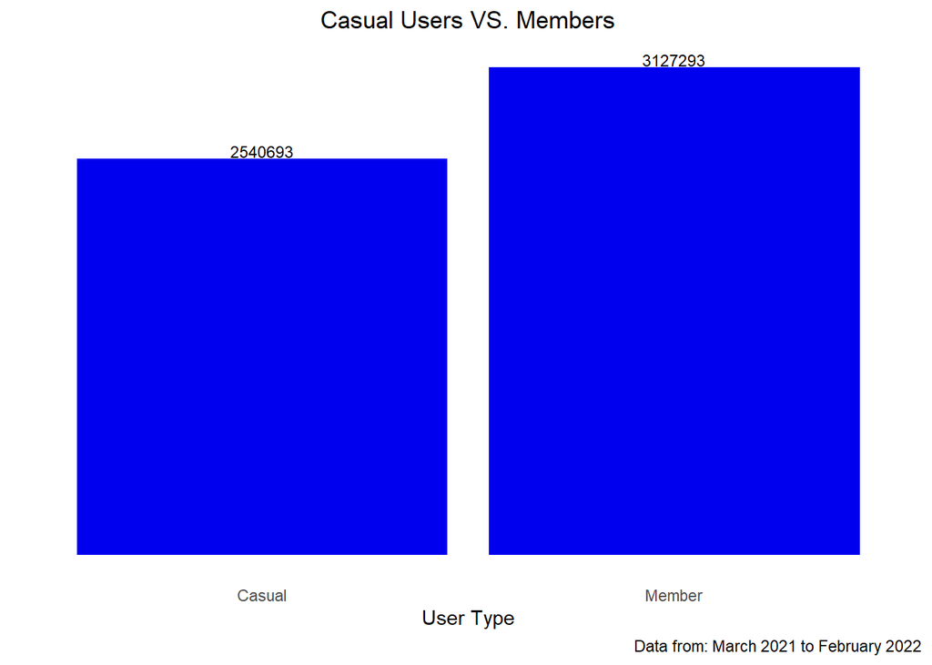

There are over 3 million members and over 2.5 million casual riders.

### Bike type count

Viewing the amount of bike types:

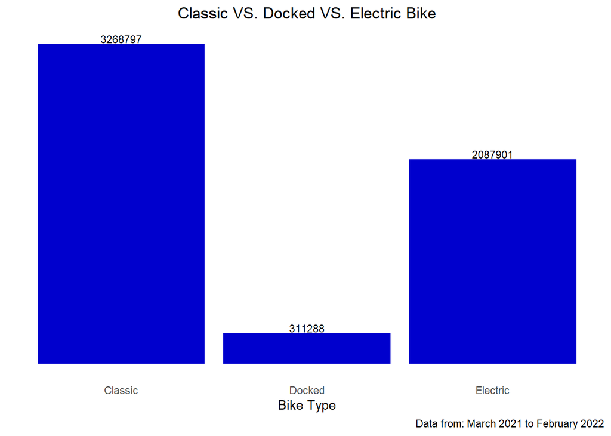

Classic bikes are the most popular, followed by electric bikes. Docked bikes have the lowest interest.

### User type and bike type

Viewing the use of bike type for casual users and members:

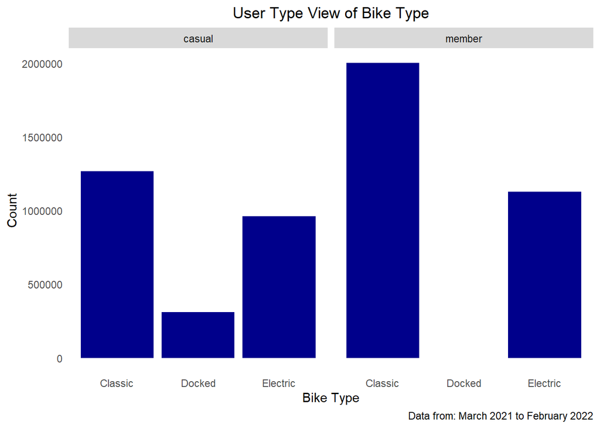

Casual users show an interest for all bikes available, and nearly just as much in electric bikes as members do. Without disturbing the use of the classic bikes available, one suggestion is to allow members exclusive access to all bikes, while casual users may continue to use classic bikes.

### Ride Length Intervals by User Type

Viewing the relationship of casual users and member against ride length intervals.

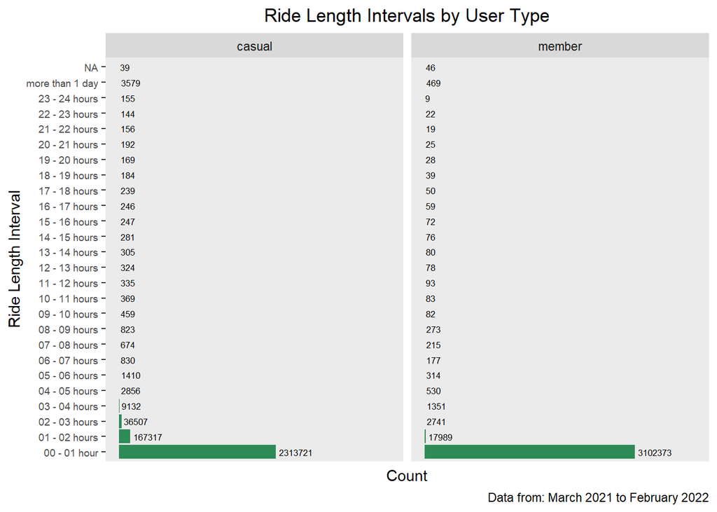

Both casual users and members primarily use cyclistic bikes for **under an hour** more than any other interval. The counts show us that all intervals occur, but with minimal frequency. There is a distinct difference for the `more than 1 day` interval. Casual users occupy bikes for more than one day, and with further analysis, we may be able to find the reason as to why. It might be economical to hold the bike for days than return the bike on a daily basis. We can’t answer this without more data. For now, it is best to set a daily limit for bike use onto casual users that encourage them to become members.

### User Type View of Ride Length Interval against Bike Type

Grid view of ride length interval against bike type by user type.

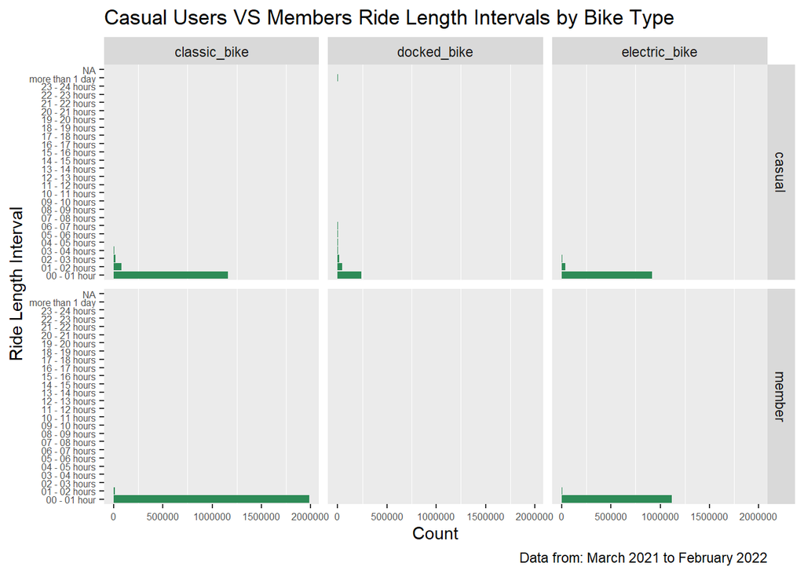

As expected, casual riders are the ones using docked bikes for several time intervals. For all bikes, interval `00 - 01 hour` is the basis.

## Weekly View

Showing how casual users and members use bikes during the week:

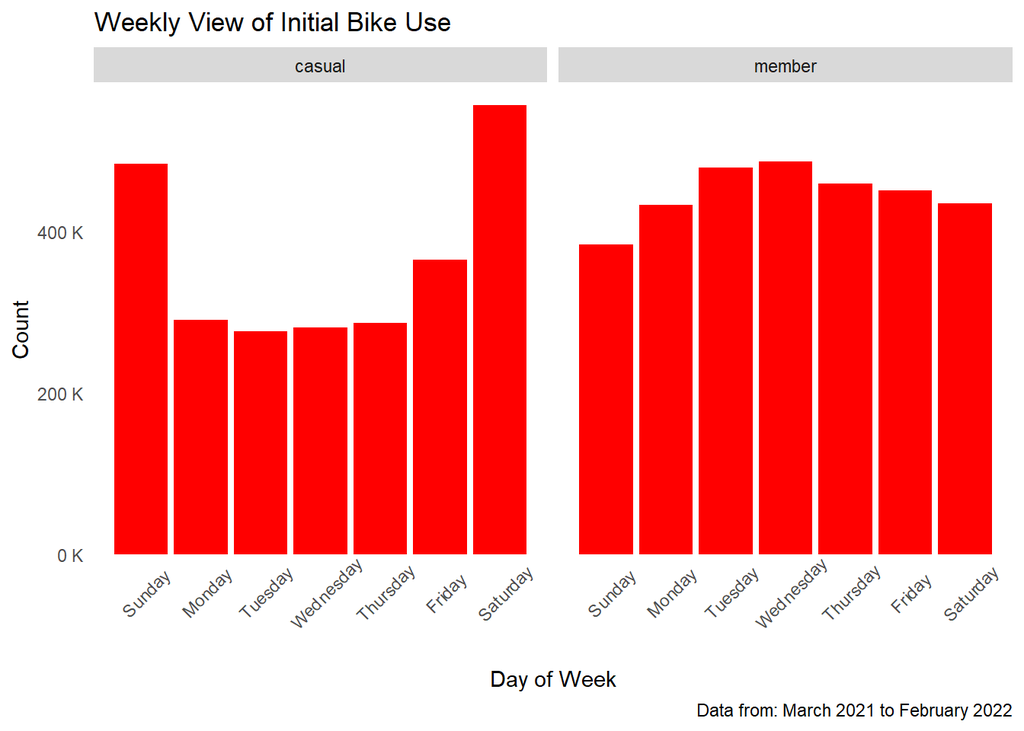

Casual users use the bikes heavily on weekends and it decreases during the week. Member use shows the opposite with heavy use during the week and decreased use on weekends.

## Yearly View

A yearly comparison for casual users and members:

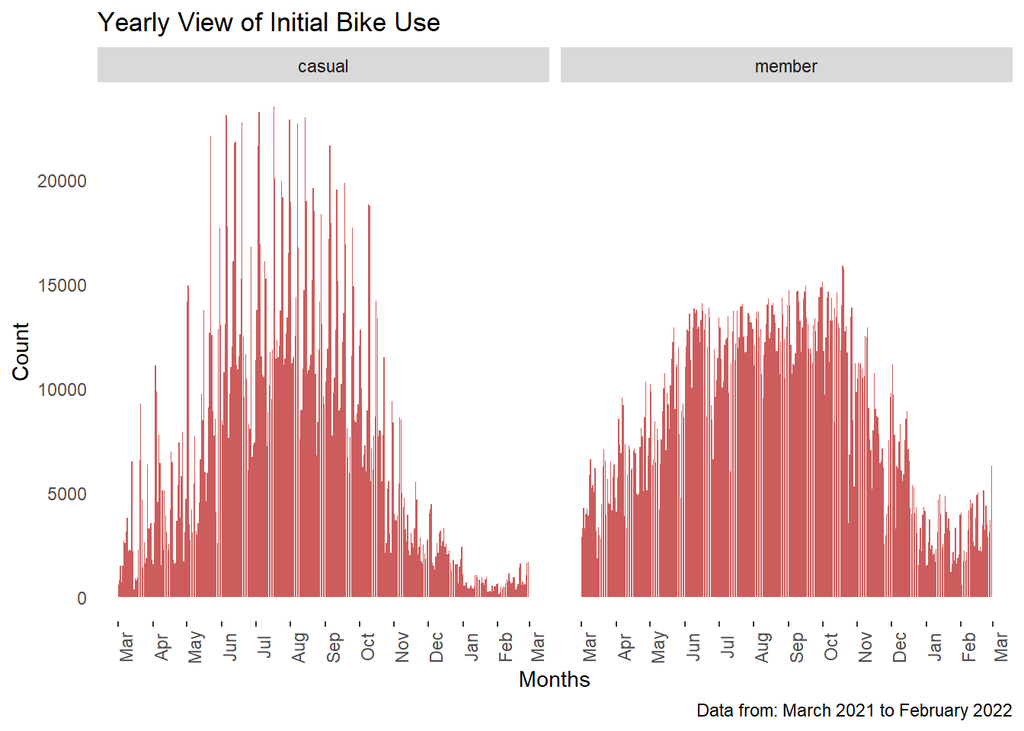

Bike use is heavily initialized in the warmer months of the year, from May into October, with casual users relying on them more than members. For casual users, bike use drastically decreases during winter and the beginning of the year, while members still rely on the bikes during this time.

## Summarize

Checking average bike ride length by bike type:

```r
## summarize for all casual users
summary <- df %>%
  group_by(member_casual,rideable_type) %>%
  summarize(mean_ride_length  =
              round(seconds_to_period(mean(period_to_seconds(ride_len),na.rm=TRUE)), digits=0),
            min_ride_length =
              seconds_to_period(min(period_to_seconds(ride_len),na.rm=TRUE)),
            max_ride_length =
              seconds_to_period(max(period_to_seconds(ride_len),na.rm=TRUE)))
head(summary)
```

```
## # A tibble: 5 x 5
## # Groups:   member_casual [2]
##   member_casual rideable_type mean_ride_length min_ride_length max_ride_length
##   <chr>         <chr>         <Period>         <Period>        <Period>
## 1 casual        classic_bike  28M 55S          -53M 0S         1d 2H 0M 0S
## 2 casual        docked_bike   1H 21M 49S       -41M 0S         38d 20H 24M 0S
## 3 casual        electric_bike 19M 43S          -58M 0S         8H 7M 0S
## 4 member        classic_bike  14M 1S           -54M 0S         1d 2H 0M 0S
## 5 member        electric_bike 12M 33S          -54M 0S         8H 1M 0S
```

Classic bikes by users have a higher average ride length at 29 minutes and members at 14 minutes. Electric bikes by users hold an average of just under 20 minutes and members at under 13 minutes. Minimum ride length as negative time does not make sense, so we move onto max ride length. Excluding docked bikes, the maximum is the same by user and bike. Classic bikes have a maximum of just over a day and electric bikes are at an 8 hour max. Docked bikes have higher averages and maximums.

## Final Findings

There are more members than casual users. Casual users favor docked bikes more than members do, with members showing zero interest in docked bikes. There is also a distinct difference for when bikes are used throughout the week. Casual users show more use of bikes on the weekends while members show more use of bikes during the week. The yearly view showed us that from May into October, bike use is much higher than the rest of the year. However, casual users drop during winter into the new year, while members continue their use.